# EasyVisa_Full_Code_Notebook-Prakash

## Data Pre-processing

### Outlier Check

```python
# Calculate Q1, Q3, and IQR for prevailing wage
Q1 = df['prevailing_wage'].quantile(0.25)
Q3 = df['prevailing_wage'].quantile(0.75)
IQR = Q3 - Q1

# Define outlier thresholds
lower_bound = Q1 - 1.5 * IQR
upper_bound = Q3 + 1.5 * IQR

# Identify outliers
outliers_wage = df[(df['prevailing_wage'] < lower_bound) | (df['prevailing_wage'] > upper_bound)]
print("outlier counts for wage" , outliers_wage.value_counts())
print(outliers_wage)
```

```
outlier counts for wage case_id    continent      education_of_employee  has_job_experience  requires_job_training  no_of_employees  yr_of_estab  region_of_employment  prevailing_wage  unit_of_wage  full_time_position  case_status
EZYV9898   Asia           High School            Y                   N                      18               2001         West                  272311.21        Year          Y                   Denied         1
EZYV10151  Asia           Bachelor's             Y                   N                      3525             1970         Island                289878.68        Year          Y                   Denied         1
EZYV10181  Asia           Doctorate              N                   N                      2705             1996         South                 227441.23        Year          N                   Certified      1
EZYV10331  North America  Master's               Y                   N                      2535             1975         Northeast             245197.29        Year          N                   Certified      1
EZYV1039   Asia           Master's               Y                   N                      538              2011         Midwest               222628.84        Year          Y                   Certified      1
                                                                                                                                                                                                                 ..
EZYV1083   Asia           Doctorate              Y                   N                      6024             1989         Northeast             274019.43        Year          Y                   Certified      1
EZYV10821  Africa         Bachelor's             N                   N                      2651             2006         West                  268713.50        Year          Y                   Certified      1
EZYV10811  Asia           Bachelor's             Y                   N                      92780            2012         West                  250163.10        Year          Y                   Certified      1
EZYV10706  Asia           High School            N                   Y                      1856             2003         West                  228715.49        Year          Y                   Denied         1
EZYV1069   Africa         Master's               N                   N                      1486             1992         Northeast             233641.72        Year          Y                   Denied         1
Name: count, Length: 427, dtype: int64
         case_id      continent education_of_employee has_job_experience  \
14        EZYV15           Asia              Master's                  Y
34        EZYV35           Asia              Master's                  N
130      EZYV131  South America           High School                  N
216      EZYV217           Asia              Master's                  Y
221      EZYV222  North America             Doctorate                  Y
...          ...            ...                   ...                ...
25191  EZYV25192           Asia              Master's                  N
25195  EZYV25196  North America              Master's                  Y
25468  EZYV25469           Asia            Bachelor's                  N
25469  EZYV25470  North America              Master's                  Y
25476  EZYV25477           Asia           High School                  Y

      requires_job_training  no_of_employees  yr_of_estab  \
14                        Y            15756         2006
34                        N             1809         2010
130                       N             2554         2005
216                       N             1515         2001
221                       Y             2518         2010
...                     ...              ...          ...
25191                     N             4983         2005
25195                     N               47         2001
25468                     N              373         2005
25469                     N             2261         1997
25476                     N             3274         2006

      region_of_employment  prevailing_wage unit_of_wage full_time_position  \
```

[output cut: 11 more lines]

```

      case_status
14      Certified
34      Certified
130     Certified
216     Certified
221     Certified
...           ...
25191      Denied
25195   Certified
25468   Certified
25469   Certified
25476   Certified

[427 rows x 12 columns]
```

### Data Preparation for modeling

```python
# Lets prepare the data.
df["case_status"] = df["case_status"].apply(lambda x: 1 if x == "Certified" else 0)
X = df.drop(["case_id"], inplace=True, axis=1)
X = df.drop(["case_status"], axis=1)

y = df["case_status"]

# Apply one-hot encoding to categorical features
categorical_cols = X.select_dtypes(include='object').columns
X = pd.get_dummies(X, columns=categorical_cols, drop_first=True)
print(X.shape)
```

```
(25480, 21)
```

```python
# Splitting data into training, validation and test set:

# first we split data into 2 parts, say temporary and test
X_train, X_temp, y_train, y_temp = train_test_split(X, y, test_size=0.3, random_state=42, stratify=y)

# then we split the temporary set into train and validation
X_val, X_test, y_val, y_test = train_test_split(X_temp, y_temp, test_size=0.5, random_state=42, stratify=y_temp)

print(X_train.shape, X_val.shape, X_test.shape)
```

```
(17836, 21) (3822, 21) (3822, 21)
```

## Model Building

### Model Evaluation Criterion

First, let's create functions to calculate different metrics and confusion matrix so that we don't have to use the same code repeatedly for each model.

- The `model_performance_classification_sklearn` function will be used to check the model performance of models.
- The `confusion_matrix_sklearn` function will be used to plot the confusion matrix.

```python
# defining a function to compute different metrics to check performance of a classification model built using sklearn


def model_performance_classification_sklearn(model, predictors, target):
    """
    Function to compute different metrics to check classification model performance

    model: classifier
    predictors: independent variables
    target: dependent variable
    """

    # predicting using the independent variables
    pred = model.predict(predictors)

    acc = accuracy_score(target, pred)  # to compute Accuracy
    recall = recall_score(target, pred)  # to compute Recall
    precision = precision_score(target, pred)  # to compute Precision
    f1 = f1_score(target, pred)  # to compute F1-score

    # creating a dataframe of metrics
    df_perf = pd.DataFrame(
        {"Accuracy": acc, "Recall": recall, "Precision": precision, "F1": f1,},
        index=[0],
    )

    return df_perf
```

```python
def confusion_matrix_sklearn(model, predictors, target):
    """
    To plot the confusion_matrix with percentages

    model: classifier
    predictors: independent variables
    target: dependent variable
    """
    y_pred = model.predict(predictors)
    cm = confusion_matrix(target, y_pred)
    labels = np.asarray(
        [
            ["{0:0.0f}".format(item) + "\n{0:.2%}".format(item / cm.flatten().sum())]
            for item in cm.flatten()
        ]
    ).reshape(2, 2)

    plt.figure(figsize=(6, 4))
    sns.heatmap(cm, annot=labels, fmt="")
    plt.ylabel("True label")
    plt.xlabel("Predicted label")
```

#### Defining scorer to be used for cross-validation and hyperparameter tuning

Let us choose the **F1 score** since that is a balance between precision and recall. We dont want people being denied visa(when they truly deserve) and also we dont want them approved when they are not supposed to be. (This might be a security issue in the USA)

```python
scorer = metrics.make_scorer(metrics.f1_score)
```

**We are now done with pre-processing and evaluation criterion, so let's start building the model.**

### Model building with Original data

```python
models = []  # Empty list to store all the models
results = []  # Empty list to store all model's CV scores
names = []  # Empty list to store name of the models

# Appending models into the list
models.append(("Bagging", BaggingClassifier(random_state=42)))
models.append(("Random forest", RandomForestClassifier(random_state=42)))
models.append(("GBM", GradientBoostingClassifier(random_state=42)))
models.append(("Adaboost", AdaBoostClassifier(random_state=42)))
models.append(("dtree", DecisionTreeClassifier(random_state=42)))
```

```python
print(X_train.shape, X_val.shape, X_test.shape)
print(y_train.shape, y_val.shape, y_test.shape)
```

```
(17836, 21) (3822, 21) (3822, 21)
(17836,) (3822,) (3822,)
```

```
Cross-Validation performance on training dataset for all the 5 models:

Bagging: 0.776902593316487

Performance: Various Parameters

   Accuracy    Recall  Precision        F1
0  0.694139  0.779083   0.766769  0.772877

Performance: Confusion Matrix

None


Random forest: 0.8062327459069424

Performance: Various Parameters

   Accuracy    Recall  Precision        F1
0   0.72449  0.840971   0.768432  0.803067

Performance: Confusion Matrix

None


GBM: 0.824619206135037

Performance: Various Parameters

   Accuracy    Recall  Precision        F1
0  0.744113  0.871524   0.773913  0.819823

Performance: Confusion Matrix

None


Adaboost: 0.8200334908816742

Performance: Various Parameters

   Accuracy  Recall  Precision        F1
0  0.731031  0.8868   0.753913  0.814975

Performance: Confusion Matrix

None


dtree: 0.7431976564222731

Performance: Various Parameters

   Accuracy    Recall  Precision        F1
0  0.657509  0.747356   0.741835  0.744585

Performance: Confusion Matrix

None
```

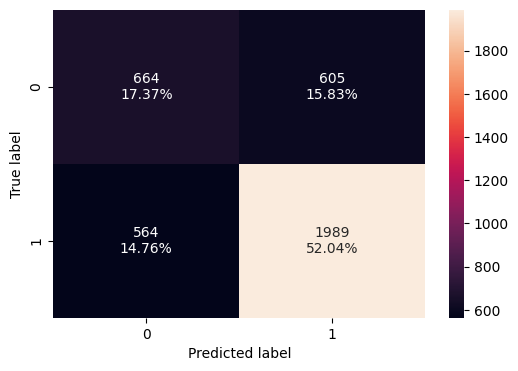

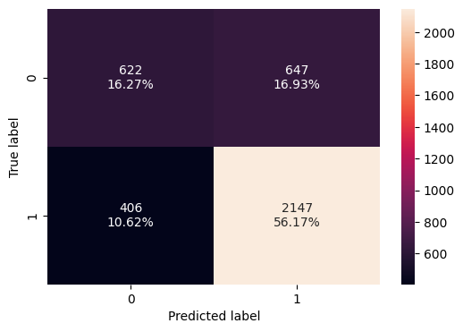

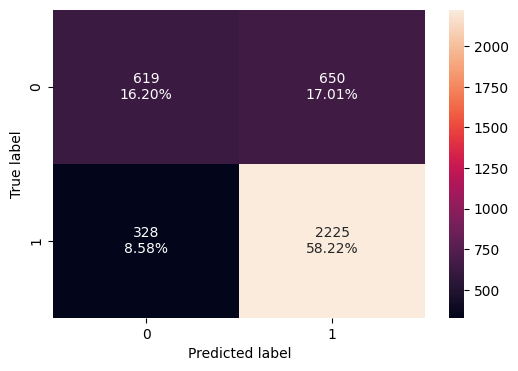

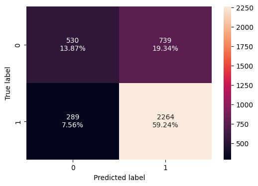

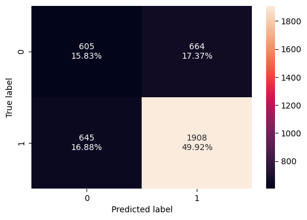

```python
# Lets cross validate
print("\n" "Cross-Validation performance on training dataset for all the 5 models:" "\n")

  #keeping the n_splits low since the running is taking a long time and also crashing the runtime engine sometimes.
kfold = StratifiedKFold(n_splits=5, shuffle=True, random_state=42)

for name, model in models:
    cv_result = cross_val_score(
        estimator=model, X=X_train, y=y_train, scoring = scorer,cv=kfold
    )
    results.append(cv_result)
    names.append(name)
    print("{}: {}".format(name, cv_result.mean()))
    model.fit(X_train,y_train)
    perf = model_performance_classification_sklearn(model, X_val, y_val)
    conf = confusion_matrix_sklearn(model, X_val, y_val)
    print("\n" "Performance: Various Parameters" "\n")
    print(perf)
    print("\n" "Performance: Confusion Matrix" "\n")
    print(conf)
    print("\n")
```

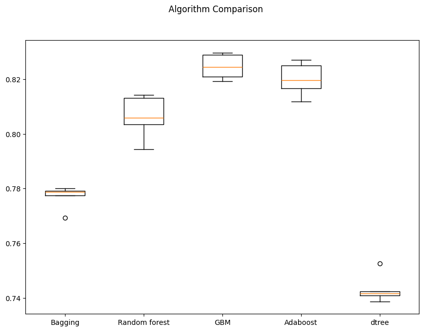

```python
#Plotting boxplots for CV scores of all models defined above
fig = plt.figure(figsize=(10, 7))

fig.suptitle("Algorithm Comparison")
ax = fig.add_subplot(111)

plt.boxplot(results)
ax.set_xticklabels(names)

plt.show()
```

### Model Building with Oversampled data

Lets check for class imbalance.

```python
# Checking class balance for whole data, train set, validation set, and test set

print("Target value ratio in y")
print(y.value_counts(1))
print("*" * 80)
print("Target value ratio in y_train")
print(y_train.value_counts(1))
print("*" * 80)
print("Target value ratio in y_val")
print(y_val.value_counts(1))
print("*" * 80)
print("Target value ratio in y_test")
print(y_test.value_counts(1))
print("*" * 80)
```

```
Target value ratio in y
case_status
1    0.667896
0    0.332104
Name: proportion, dtype: float64
Target value ratio in y_train
case_status
1    0.667919
0    0.332081
Name: proportion, dtype: float64
Target value ratio in y_val
case_status
1    0.667975
0    0.332025
Name: proportion, dtype: float64
Target value ratio in y_test
case_status
1    0.667713
0    0.332287
Name: proportion, dtype: float64
```

```python
print("Before OverSampling, counts of label '1': {}".format(sum(y_train == 1)))
print("Before OverSampling, counts of label '0': {} \n".format(sum(y_train == 0)))

# Synthetic Minority Over Sampling Technique
sm = SMOTE(sampling_strategy=1, k_neighbors=5, random_state=42)
X_train_over, y_train_over = sm.fit_resample(X_train, y_train)


print("After OverSampling, counts of label '1': {}".format(sum(y_train_over == 1)))
print("After OverSampling, counts of label '0': {} \n".format(sum(y_train_over == 0)))


print("After OverSampling, the shape of train_X: {}".format(X_train_over.shape))
print("After OverSampling, the shape of train_y: {} \n".format(y_train_over.shape))
```

```
Before OverSampling, counts of label '1': 11913
Before OverSampling, counts of label '0': 5923

After OverSampling, counts of label '1': 11913
After OverSampling, counts of label '0': 11913

After OverSampling, the shape of train_X: (23826, 21)
After OverSampling, the shape of train_y: (23826,)
```

```
Cross-Validation performance on training dataset using oversampled data:

Bagging: 0.7615542807808515

Performance: Various Parameters

   Accuracy    Recall  Precision        F1
0  0.693093  0.762241   0.774682  0.768411

Performance: Confusion Matrix

None


Random forest: 0.7927067506689416

Performance: Various Parameters

   Accuracy    Recall  Precision       F1
0  0.719257  0.817861   0.774481  0.79558

Performance: Confusion Matrix

None


GBM: 0.8050749813829021

Performance: Various Parameters

   Accuracy    Recall  Precision        F1
0  0.743328  0.854289    0.78172  0.816395

Performance: Confusion Matrix

None


Adaboost: 0.7908741049483738

Performance: Various Parameters

   Accuracy    Recall  Precision        F1
0  0.731816  0.855464   0.769014  0.809939

Performance: Confusion Matrix

None


dtree: 0.7301740046260312

Performance: Various Parameters

   Accuracy    Recall  Precision        F1
0  0.650183  0.732863   0.740697  0.736759

Performance: Confusion Matrix

None
```

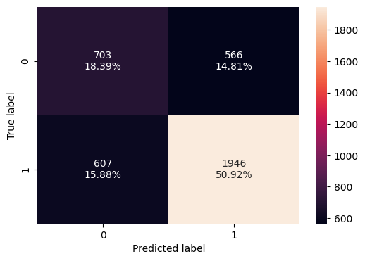

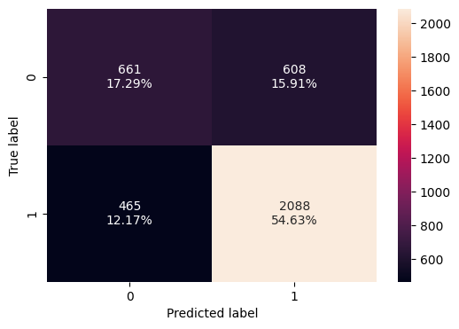

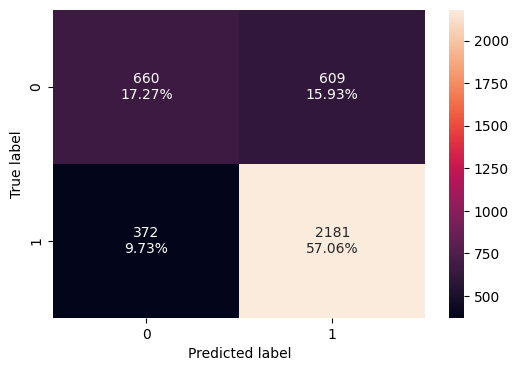

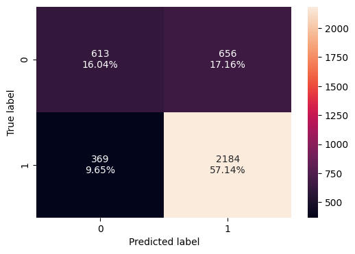

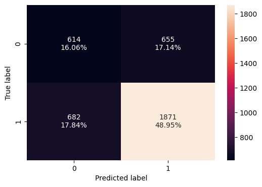

```python
models = []  # Empty list to store all the models
results = []  # Empty list to store all model's CV scores
names = []  # Empty list to store name of the models

# Appending models into the list
models.append(("Bagging", BaggingClassifier(random_state=42)))
models.append(("Random forest", RandomForestClassifier(random_state=42)))
models.append(("GBM", GradientBoostingClassifier(random_state=42)))
models.append(("Adaboost", AdaBoostClassifier(random_state=42)))
models.append(("dtree", DecisionTreeClassifier(random_state=42)))

# loop through all models to get the mean cross validated score
print("\n" "Cross-Validation performance on training dataset using oversampled data:" "\n")
kfold = StratifiedKFold(n_splits=5, shuffle=True, random_state=1)

for name, model in models:
    cv_result = cross_val_score(
        estimator=model, X=X_train_over, y=y_train_over,scoring = scorer, cv=kfold
    )
    results.append(cv_result)
    names.append(name)
    print("{}: {}".format(name, cv_result.mean()))
    model.fit(X_train_over,y_train_over)
    perf = model_performance_classification_sklearn(model, X_val, y_val)
    conf = confusion_matrix_sklearn(model, X_val, y_val)
    print("\n" "Performance: Various Parameters" "\n")
    print(perf)
    print("\n" "Performance: Confusion Matrix" "\n")
    print(conf)
    print("\n")
```

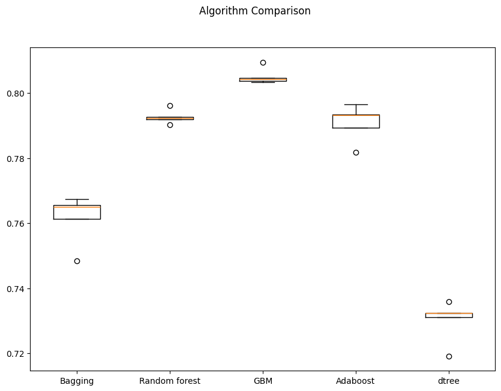

```python
# Plotting boxplots for CV scores of all models defined above
fig = plt.figure(figsize=(10, 7))

fig.suptitle("Algorithm Comparison")
ax = fig.add_subplot(111)

plt.boxplot(results)
ax.set_xticklabels(names)

plt.show()
```

### Model Building with Undersampled data

```python
rus = RandomUnderSampler(random_state=42, sampling_strategy=1)
X_train_un, y_train_un = rus.fit_resample(X_train, y_train)


print("Before UnderSampling, counts of label '1': {}".format(sum(y_train == 1)))
print("Before UnderSampling, counts of label '0': {} \n".format(sum(y_train == 0)))


print("After UnderSampling, counts of label '1': {}".format(sum(y_train_un == 1)))
print("After UnderSampling, counts of label '0': {} \n".format(sum(y_train_un == 0)))


print("After UnderSampling, the shape of train_X: {}".format(X_train_un.shape))
print("After UnderSampling, the shape of train_y: {} \n".format(y_train_un.shape))
```

```
Before UnderSampling, counts of label '1': 11913
Before UnderSampling, counts of label '0': 5923

After UnderSampling, counts of label '1': 5923
After UnderSampling, counts of label '0': 5923

After UnderSampling, the shape of train_X: (11846, 21)
After UnderSampling, the shape of train_y: (11846,)
```

```
Cross-Validation performance on training dataset using undersampled data:

Bagging: 0.648227026875054

Performance: Various Parameters

   Accuracy    Recall  Precision        F1
0  0.644689  0.609087    0.81201  0.696061

Performance: Confusion Matrix

None


Random forest: 0.6883663664092916

Performance: Various Parameters

   Accuracy    Recall  Precision        F1
0   0.68001  0.681943   0.809015  0.740064

Performance: Confusion Matrix

None


GBM: 0.7131226753112041

Performance: Various Parameters

   Accuracy    Recall  Precision        F1
0   0.70853  0.732863   0.812419  0.770593

Performance: Confusion Matrix

None


Adaboost: 0.7048541754838573

Performance: Various Parameters

   Accuracy    Recall  Precision       F1
0  0.694924  0.724246   0.800087  0.76028

Performance: Confusion Matrix

None


dtree: 0.6213718649289948

Performance: Various Parameters

   Accuracy    Recall  Precision        F1
0  0.623234  0.636898   0.760168  0.693095

Performance: Confusion Matrix

None
```

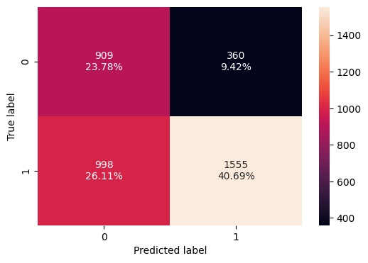

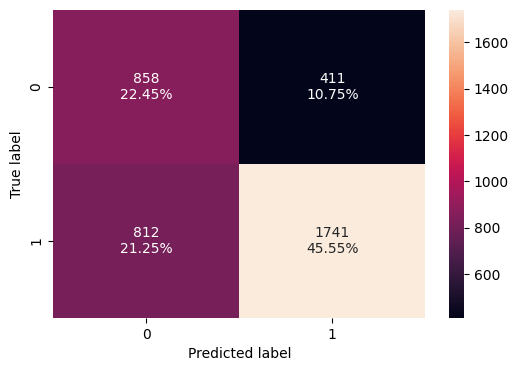

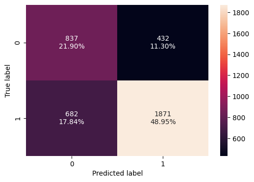

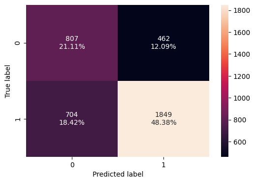

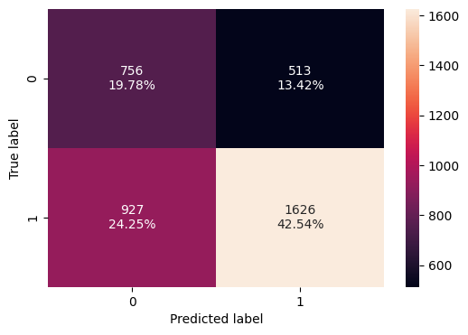

```python
models = []  # Empty list to store all the models
results = []  # Empty list to store all model's CV scores
names = []  # Empty list to store name of the models

# Appending models into the list
models.append(("Bagging", BaggingClassifier(random_state=42)))
models.append(("Random forest", RandomForestClassifier(random_state=42)))
models.append(("GBM", GradientBoostingClassifier(random_state=42)))
models.append(("Adaboost", AdaBoostClassifier(random_state=42)))
models.append(("dtree", DecisionTreeClassifier(random_state=42)))


# loop through all models to get the mean cross validated score
print("\n" "Cross-Validation performance on training dataset using undersampled data:" "\n")
kfold = StratifiedKFold(n_splits=5, shuffle=True, random_state=42)

for name, model in models:
    cv_result = cross_val_score(estimator=model, X=X_train_un, y=y_train_un,scoring = scorer, cv=kfold)
    results.append(cv_result)
    names.append(name)
    print("{}: {}".format(name, cv_result.mean()))
    model.fit(X_train_un,y_train_un)
    perf = model_performance_classification_sklearn(model, X_val, y_val)
    conf = confusion_matrix_sklearn(model, X_val, y_val)
    print("\n" "Performance: Various Parameters" "\n")
    print(perf)
    print("\n" "Performance: Confusion Matrix" "\n")
    print(conf)
    print("\n")
```

## Hyperparameter Tuning

**The 3 models that will be used for Hyperparameter tuning**

RandomForest - with oversampling  
GBM - with oversampling  
AdaBoost - with oversampling.

**Best practices for hyperparameter tuning in AdaBoost:**

`n_estimators`:

- Start with a specific number (50 is used in general) and increase in steps: 50, 75, 85, 100
- Use fewer estimators (e.g., 50 to 100) if using complex base learners (like deeper decision trees)
- Use more estimators (e.g., 100 to 150) when learning rate is low (e.g., 0.1 or lower)
- Avoid very high values unless performance keeps improving on validation

`learning_rate`:

- Common values to try: 1.0, 0.5, 0.1, 0.01
- Use 1.0 for faster training, suitable for fewer estimators
- Use 0.1 or 0.01 when using more estimators to improve generalization
- Avoid very small values (< 0.01) unless you plan to use many estimators (e.g., >500) and have sufficient data

```python
%%time

# defining model
model = AdaBoostClassifier(random_state=42)

# Parameter grid to pass in RandomSearchCV
param_grid = {
    "n_estimators": [50, 75, 85, 100],
    "learning_rate": [0.01, 0.1, 0.5, 1],
    "estimator": [DecisionTreeClassifier(max_depth=1, random_state=42), DecisionTreeClassifier(max_depth=2, random_state=42), DecisionTreeClassifier(max_depth=3, random_state=42),
    ]
}

#Calling RandomizedSearchCV
kfold = StratifiedKFold(n_splits=5, shuffle=True, random_state=42)

randomized_cv = RandomizedSearchCV(
    estimator=model,
    param_distributions=param_grid,
    n_iter=7,
    scoring=scorer,
    cv=kfold,
    random_state=42
)

#Fitting parameters in RandomizedSearchCV
randomized_cv.fit(X_train_over,y_train_over)

# Print the best combination of parameters
adaboost_bestparams = randomized_cv.best_params_
adaboost_bestmodel = randomized_cv.best_estimator_
print("Best parameters: ", adaboost_bestparams)
print("Best model: ", adaboost_bestmodel)

adaboost_train = model_performance_classification_sklearn(adaboost_bestmodel, X_train_over, y_train_over)
adaboost_val = model_performance_classification_sklearn(adaboost_bestmodel, X_val, y_val)

print("\n" "Train Performance:" "\n")
print(adaboost_train)
print("\n" "Validation Performance:" "\n")
print(adaboost_val)
print("\n")
```

```
Best parameters:  {'n_estimators': 100, 'learning_rate': 0.5, 'estimator': DecisionTreeClassifier(max_depth=3, random_state=42)}
Best model:  AdaBoostClassifier(estimator=DecisionTreeClassifier(max_depth=3,
                                                    random_state=42),
                   learning_rate=0.5, n_estimators=100, random_state=42)

Train Performance:

   Accuracy    Recall  Precision        F1
0  0.791908  0.856879   0.758339  0.804603

Validation Performance:

   Accuracy    Recall  Precision        F1
0  0.735217  0.852722   0.773907  0.811405


CPU times: user 1min 3s, sys: 78.1 ms, total: 1min 3s
Wall time: 1min 3s
```

**Best practices for hyperparameter tuning in Random Forest:**

`n_estimators`:

- Start with a specific number (50 is used in general) and increase in steps: 50, 75, 100, 125
- Higher values generally improve performance but increase training time
- Use 100-150 for large datasets or when variance is high

`min_samples_leaf`:

- Try values like: 1, 2, 4, 5, 10
- Higher values reduce model complexity and help prevent overfitting
- Use 1–2 for low-bias models, higher (like 5 or 10) for more regularized models
- Works well in noisy datasets to smooth predictions

`max_features`:

- Try values: `"sqrt"` (default for classification), `"log2"`, `None`, or float values (e.g., `0.3`, `0.5`)
- `"sqrt"` balances between diversity and performance for classification tasks
- Lower values (e.g., `0.3`) increase tree diversity, reducing overfitting
- Higher values (closer to `1.0`) may capture more interactions but risk overfitting

`max_samples` (for bootstrap sampling):

- Try float values between `0.5` to `1.0` or fixed integers
- Use `0.6–0.9` to introduce randomness and reduce overfitting
- Smaller values increase diversity between trees, improving generalization

```python
%%time

# defining model
model = RandomForestClassifier(random_state=42)

# Parameter grid to pass in RandomSearchCV
param_grid = {
    "n_estimators": [50, 75, 100, 125], ## Complete the code to set the number of estimators.
    "min_samples_leaf": [2, 4, 5], ## Complete the code to set the minimum number of samples in the leaf node.
    "max_features": [0.3, 0.5], ## Complete the code to set the maximum number of features.
    "max_samples": [0.6, 0.9], ## Complete the code to set the maximum number of samples.
}


#Calling RandomizedSearchCV
kfold = StratifiedKFold(n_splits=5, shuffle=True, random_state=42)
randomized_cv = RandomizedSearchCV(
    estimator=model,
    param_distributions=param_grid,
    n_iter=7,
    scoring=scorer,
    cv=kfold,
    random_state=42
)

#Fitting parameters in RandomizedSearchCV
randomized_cv.fit(X_train_over, y_train_over)
randomForest_bestparams = randomized_cv.best_params_
randomForest_bestmodel = randomized_cv.best_estimator_
print("Best parameters: ", randomForest_bestparams)
print("Best model: ", randomForest_bestmodel)

# perf = model_performance_classification_sklearn(randomForest_bestmodel, X_val, y_val)
# conf = confusion_matrix_sklearn(randomForest_bestmodel, X_val, y_val)
randomForest_trained = model_performance_classification_sklearn(randomForest_bestmodel, X_train_over, y_train_over)
randomForest_val = model_performance_classification_sklearn(randomForest_bestmodel, X_val, y_val)
print("\n" "Performance:" "\n")
print("\n" "Train Performance:" "\n")
print(randomForest_trained)
print("\n" "Validation Performance:" "\n")
print(randomForest_val)
print("\n")
```

```
Best parameters:  {'n_estimators': 50, 'min_samples_leaf': 2, 'max_samples': 0.9, 'max_features': 0.3}
Best model:  RandomForestClassifier(max_features=0.3, max_samples=0.9, min_samples_leaf=2,
                       n_estimators=50, random_state=42)

Performance:


Train Performance:

   Accuracy    Recall  Precision        F1
0   0.92781  0.953916   0.906582  0.929647

Validation Performance:

   Accuracy    Recall  Precision        F1
0  0.732601  0.835879   0.779686  0.806805


CPU times: user 1min 28s, sys: 91.7 ms, total: 1min 28s
Wall time: 1min 28s
```

**Best practices for hyperparameter tuning in Gradient Boosting:**

`n_estimators`:

- Start with 100 (default) and increase: 100, 200, 300, 500
- Typically, higher values lead to better performance, but they also increase training time
- Use 200–500 for larger datasets or complex problems
- Monitor validation performance to avoid overfitting, as too many estimators can degrade generalization

`learning_rate`:

- Common values to try: 0.1, 0.05, 0.01, 0.005
- Use lower values (e.g., 0.01 or 0.005) if you are using many estimators (e.g., > 200)
- Higher learning rates (e.g., 0.1) can be used with fewer estimators for faster convergence
- Always balance the learning rate with `n_estimators` to prevent overfitting or underfitting

`subsample`:

- Common values: 0.7, 0.8, 0.9, 1.0
- Use a value between `0.7` and `0.9` for improved generalization by introducing randomness
- `1.0` uses the full dataset for each boosting round, potentially leading to overfitting
- Reducing `subsample` can help reduce overfitting, especially in smaller datasets

`max_features`:

- Common values: `"sqrt"`, `"log2"`, or float (e.g., `0.3`, `0.5`)
- `"sqrt"` (default) works well for classification tasks
- Lower values (e.g., `0.3`) help reduce overfitting by limiting the number of features considered at each split

```python
%%time

# defining model
model = GradientBoostingClassifier(random_state=1)

param_grid={
    "n_estimators": [50,100,150, 200, 250],
    "learning_rate": [0.1, 0.05, 0.01, 0.005],
    "subsample":[0.7, 0.8, 0.9, 1.0],
    "max_features":[0.3, 0.5]
}

#Calling RandomizedSearchCV
kfold = StratifiedKFold(n_splits=5, shuffle=True, random_state=42)
randomized_cv = RandomizedSearchCV(
    estimator=model,
    param_distributions=param_grid,
    n_iter=7,
    scoring=scorer,
    cv=kfold,
    random_state=1
)

#Fitting parameters in RandomizedSearchCV
randomized_cv.fit(X_train_over, y_train_over)
gbBoost_bestparams = randomized_cv.best_params_
gbBoost_bestmodel = randomized_cv.best_estimator_
print("Best GD Boost parameters: ", gbBoost_bestparams)
print("Best GD Boost model: ", gbBoost_bestmodel)

gbm_trained = model_performance_classification_sklearn(gbBoost_bestmodel, X_train_over, y_train_over)
gbm_val = model_performance_classification_sklearn(gbBoost_bestmodel, X_val, y_val)
print("\n" "Performance: on trained data" "\n")
print(gbm_trained)
print("\n" "Performance: on validated data" "\n")
print(gbm_val)
print("\n")
```

```
Best GD Boost parameters:  {'subsample': 1.0, 'n_estimators': 250, 'max_features': 0.3, 'learning_rate': 0.1}
Best GD Boost model:  GradientBoostingClassifier(max_features=0.3, n_estimators=250, random_state=1)

Performance: on trained data

   Accuracy    Recall  Precision        F1
0  0.802233  0.863007   0.769478  0.813563

Performance: on validated data

   Accuracy    Recall  Precision        F1
0   0.74202  0.857031   0.778925  0.816113


CPU times: user 51.3 s, sys: 69.3 ms, total: 51.3 s
Wall time: 51.4 s
```

## Model Performance Summary and Final Model Selection

**We will go with the GBM model since they gave the best F1 scores.**

The details have been provided in the table(s) below

```python
# training performance comparison
models_train_comp_df = pd.concat(
    [
        gbm_trained.T,
        adaboost_train.T,
        randomForest_trained.T
    ],
    axis=1,
)
models_train_comp_df.columns = [
    "GBM (oversampled)",
    "AdaBoost (oversampled)",
    "Random forest (oversampled)",
]
print("Training performance comparison:")
models_train_comp_df
```

```
Training performance comparison:
```

|  | GBM (oversampled) | AdaBoost (oversampled) | Random forest (oversampled) |
| --- | --- | --- | --- |
| Accuracy | 0.802233 | 0.791908 | 0.927810 |
| Recall | 0.863007 | 0.856879 | 0.953916 |
| Precision | 0.769478 | 0.758339 | 0.906582 |
| F1 | 0.813563 | 0.804603 | 0.929647 |

```python
# validation performance comparison

models_val_comp_df = pd.concat(
    [
        gbm_val.T,
        adaboost_val.T,
        randomForest_val.T,
    ],
    axis=1,
)
models_val_comp_df.columns = [
    "GBM (oversampled)",
    "AdaBoost (oversampled)",
    "Random forest (oversampled)",
]
print("Validation performance comparison:")
models_val_comp_df
```

```
Validation performance comparison:
```

|  | GBM (oversampled) | AdaBoost (oversampled) | Random forest (oversampled) |
| --- | --- | --- | --- |
| Accuracy | 0.742020 | 0.735217 | 0.732601 |
| Recall | 0.857031 | 0.852722 | 0.835879 |
| Precision | 0.778925 | 0.773907 | 0.779686 |
| F1 | 0.816113 | 0.811405 | 0.806805 |

As we can see that the gradient boosting with oversampling gives consistent results in training and validation.  
The F1 scores are 0.813 and 0.816.  
So we will go with that.

```python
final_model = gbBoost_bestmodel
```

```
   Accuracy    Recall  Precision        F1
0   0.73888  0.852273   0.777897  0.813388
```

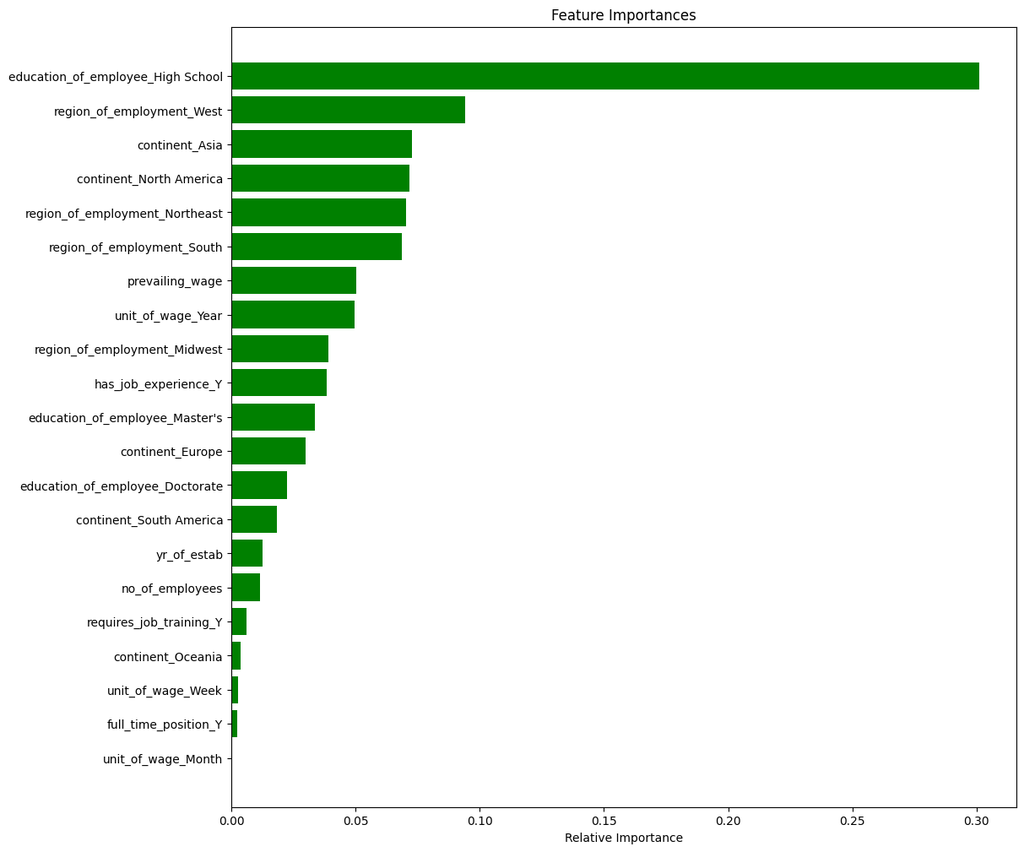

```python
production_model = model_performance_classification_sklearn(final_model, X_test, y_test)
print(production_model)
print("\n")

feature_names = X_train.columns
importances = final_model.feature_importances_
indices = np.argsort(importances)

plt.figure(figsize=(12, 12))
plt.title("Feature Importances")
plt.barh(range(len(indices)), importances[indices], color="green", align="center")
plt.yticks(range(len(indices)), [feature_names[i] for i in indices])
plt.xlabel("Relative Importance")
plt.show()
```

## Actionable Insights and Recommendations

Power Ahead

The gradient boosting model gives the best F1 scores.

- The F1 scores are pretty consistent across training, validation and test which shows very clearly that we have not overfit.

In order to increase the likeliness of a visa certification (approval)

1. Have a PhD or a masters degree
2. Being from Europe or Africa incrases the chances.
3. Having prior work experience also increases the changes
4. Having yearly wage also increases the chances.

We can conclude that we need to let the visa aspirants know that they need to study hard and get at least a bachelors and have work experience. This would surely increase their chances of getting a visa approved.